# TCP Tahoe And Reno

Austin Coates and Malak Patel

4/7/2017

https://inst.eecs.berkeley.edu/~ee122/fa05/projects/Project2/SACKRENEVEGAS.pdf

# First Our Python Simulator

## Tahoe

TCP Tahoe is a protocol usually used to refer to the TCP congestion algorithim. Tahoe runs with the TCP principle of conservation of packets, so there are no packets being injected into a network that is already filled. Tahoe also has a congestion window, to show the network capacity, as to know when to cut the window size and increment slowly as to avoid packet loss and congestion. For our implementation of Tahoe, we executed a single packet system, sending eacho packet using an individual thread, but instead of the quick recovery of Reno we used regular TCP recovery which has a large loss of window size and overall efficiency.

```r
library(ggplot2)
library(readr)
library(reshape)
library(reshape2)
tahoe <- read_csv("~/networking/tahoe.csv")
mdata1 <- dcast(tahoe, Seq ~ type)
mdata1$throughput <- (mdata1$Rec - mdata1$sent)
head(mdata1)
```

```
##   Seq        Rec       sent throughput
## 1   1 1491541927 1491541926          1
## 2   2 1491541928 1491541927          1
## 3   3 1491541929 1491541928          1
## 4   4 1491541930 1491541929          1
## 5   5 1491541931 1491541930          1
## 6   6 1491541932 1491541931          1
```

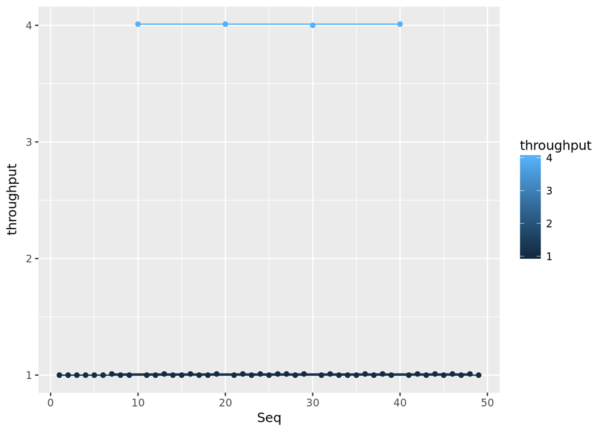

```r
ggplot(data=mdata1, aes(x=Seq, y=throughput, group=throughput, colour=throughput)) + geom_line() + geom_point()
```

```r
# X axis would be the range of times, while y axis is the value of the throughput.
```

## Reno

Reno retains all od the basic principles you see in Tahoe, such as slow starts, and the re-transmit timer. The differnece is, the lost packets are detected earlier in the pipeline, and the window size is halfed, not reduced to one. For Reno, we executed a single packet sending technique using threads, but implemented a fast recovery to not have a large loss of the window size, which really hurts the overall throughput.

```r
library(ggplot2)
library(readr)
library(reshape2)
file <- read_csv("~/networking/file.csv")
temp<-c("Seq","type","time")
file<-file[temp]
mdata2 <- dcast(file, Seq ~ type)
mdata2$throughput <- (mdata2$Rec - mdata2$sent)
head(mdata2)
```

```
##   Seq        Rec       sent throughput
## 1   1 1491540516 1491540514       2.01
## 2   2 1491540518 1491540516       2.00
## 3   3 1491540520 1491540518       2.00
## 4   4 1491540522 1491540520       2.00
## 5   5 1491540524 1491540522       2.00
## 6   6 1491540526 1491540524       2.00
```

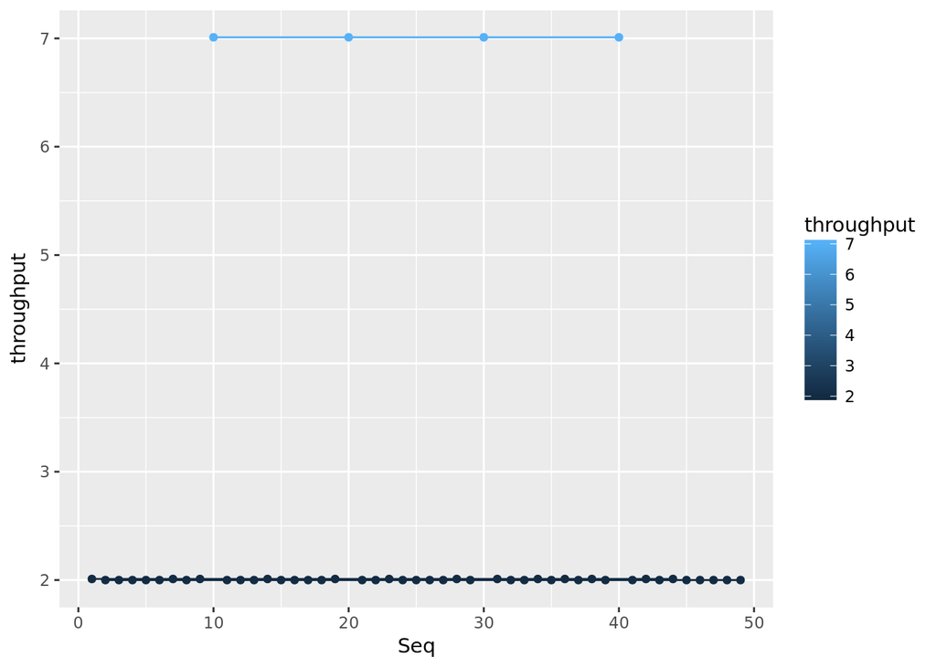

```r
ggplot(data=mdata2, aes(x=Seq, y=throughput, group=throughput, colour=throughput)) + geom_line() + geom_point()
```

# Next Our C Simulator

## Reno

To simulate we put in the following input, to get fairly interesting results. Unfortunately, I can say our output was not what we wanted, and without the proper check summing and lack of understanding even though we read through the simulators code, the packet loss was not doing what we wished for it to do so we just adjusted the time between packets being sent to account for the difference we expected.

Enter the number of messages to simulate: 20  
Enter packet loss probability [enter 0.0 for no loss]:0.5  
Enter packet corruption probability [0.0 for no corruption]:0.5  
Enter average time between messages from sender’s layer5 [ > 0.0]:10

Enter TRACE:3  
GENERATE NEXT ARRIVAL: creating new arrival  
INSERTEVENT: time is 0.000000  
INSERTEVENT: future time will be 6.965711

EVENT time: 6.965711, type: 1, fromlayer5 entity: 0  
GENERATE NEXT ARRIVAL: creating new arrival  
INSERTEVENT: time is 6.965711  
INSERTEVENT: future time will be 19.661861  
MAINLOOP: data given to student: aaaaaaaaaaaaaaaaaaaa

EVENT time: 19.661861, type: 1, fromlayer5 entity: 0  
GENERATE NEXT ARRIVAL: creating new arrival  
INSERTEVENT: time is 19.661861  
INSERTEVENT: future time will be 23.864265  
MAINLOOP: data given to student: bbbbbbbbbbbbbbbbbbbb

EVENT time: 23.864265, type: 1, fromlayer5 entity: 0  
GENERATE NEXT ARRIVAL: creating new arrival  
INSERTEVENT: time is 23.864265  
INSERTEVENT: future time will be 33.661812  
MAINLOOP: data given to student: cccccccccccccccccccc

EVENT time: 33.661812, type: 1, fromlayer5 entity: 0  
GENERATE NEXT ARRIVAL: creating new arrival  
INSERTEVENT: time is 33.661812  
INSERTEVENT: future time will be 41.035625  
MAINLOOP: data given to student: dddddddddddddddddddd

EVENT time: 41.035625, type: 1, fromlayer5 entity: 0  
GENERATE NEXT ARRIVAL: creating new arrival  
INSERTEVENT: time is 41.035625  
INSERTEVENT: future time will be 52.703880  
MAINLOOP: data given to student: eeeeeeeeeeeeeeeeeeee

EVENT time: 52.703880, type: 1, fromlayer5 entity: 0  
GENERATE NEXT ARRIVAL: creating new arrival  
INSERTEVENT: time is 52.703880  
INSERTEVENT: future time will be 61.055321  
MAINLOOP: data given to student: ffffffffffffffffffff

EVENT time: 61.055321, type: 1, fromlayer5 entity: 0  
GENERATE NEXT ARRIVAL: creating new arrival  
INSERTEVENT: time is 61.055321  
INSERTEVENT: future time will be 63.745209  
MAINLOOP: data given to student: gggggggggggggggggggg

EVENT time: 63.745209, type: 1, fromlayer5 entity: 0  
GENERATE NEXT ARRIVAL: creating new arrival  
INSERTEVENT: time is 63.745209  
INSERTEVENT: future time will be 72.725754  
MAINLOOP: data given to student: hhhhhhhhhhhhhhhhhhhh

EVENT time: 72.725754, type: 1, fromlayer5 entity: 0  
GENERATE NEXT ARRIVAL: creating new arrival  
INSERTEVENT: time is 72.725754  
INSERTEVENT: future time will be 88.784477  
MAINLOOP: data given to student: iiiiiiiiiiiiiiiiiiii

EVENT time: 88.784477, type: 1, fromlayer5 entity: 0  
GENERATE NEXT ARRIVAL: creating new arrival  
INSERTEVENT: time is 88.784477  
INSERTEVENT: future time will be 107.735878  
MAINLOOP: data given to student: jjjjjjjjjjjjjjjjjjjj

EVENT time: 107.735878, type: 1, fromlayer5 entity: 0  
GENERATE NEXT ARRIVAL: creating new arrival  
INSERTEVENT: time is 107.735878  
INSERTEVENT: future time will be 123.945984  
MAINLOOP: data given to student: kkkkkkkkkkkkkkkkkkkk

EVENT time: 123.945984, type: 1, fromlayer5 entity: 0  
GENERATE NEXT ARRIVAL: creating new arrival  
INSERTEVENT: time is 123.945984  
INSERTEVENT: future time will be 127.191025  
MAINLOOP: data given to student: llllllllllllllllllll

EVENT time: 127.191025, type: 1, fromlayer5 entity: 0  
GENERATE NEXT ARRIVAL: creating new arrival  
INSERTEVENT: time is 127.191025  
INSERTEVENT: future time will be 146.531555  
MAINLOOP: data given to student: mmmmmmmmmmmmmmmmmmmm

EVENT time: 146.531555, type: 1, fromlayer5 entity: 0  
GENERATE NEXT ARRIVAL: creating new arrival  
INSERTEVENT: time is 146.531555  
INSERTEVENT: future time will be 162.758072  
MAINLOOP: data given to student: nnnnnnnnnnnnnnnnnnnn

EVENT time: 162.758072, type: 1, fromlayer5 entity: 0  
GENERATE NEXT ARRIVAL: creating new arrival  
INSERTEVENT: time is 162.758072  
INSERTEVENT: future time will be 181.764923  
MAINLOOP: data given to student: oooooooooooooooooooo

EVENT time: 181.764923, type: 1, fromlayer5 entity: 0  
GENERATE NEXT ARRIVAL: creating new arrival  
INSERTEVENT: time is 181.764923  
INSERTEVENT: future time will be 189.809158  
MAINLOOP: data given to student: pppppppppppppppppppp

EVENT time: 189.809158, type: 1, fromlayer5 entity: 0  
GENERATE NEXT ARRIVAL: creating new arrival  
INSERTEVENT: time is 189.809158  
INSERTEVENT: future time will be 209.339005  
MAINLOOP: data given to student: qqqqqqqqqqqqqqqqqqqq

EVENT time: 209.339005, type: 1, fromlayer5 entity: 0  
GENERATE NEXT ARRIVAL: creating new arrival  
INSERTEVENT: time is 209.339005  
INSERTEVENT: future time will be 227.398163  
MAINLOOP: data given to student: rrrrrrrrrrrrrrrrrrrr

EVENT time: 227.398163, type: 1, fromlayer5 entity: 0  
GENERATE NEXT ARRIVAL: creating new arrival  
INSERTEVENT: time is 227.398163  
INSERTEVENT: future time will be 227.741928  
MAINLOOP: data given to student: ssssssssssssssssssss

EVENT time: 227.741928, type: 1, fromlayer5 entity: 0  
GENERATE NEXT ARRIVAL: creating new arrival  
INSERTEVENT: time is 227.741928  
INSERTEVENT: future time will be 245.443665  
MAINLOOP: data given to student: tttttttttttttttttttt

EVENT time: 245.443665, type: 1, fromlayer5 entity: 0  
Simulator terminated at time 245.443665  
after sending 20 msgs from layer5

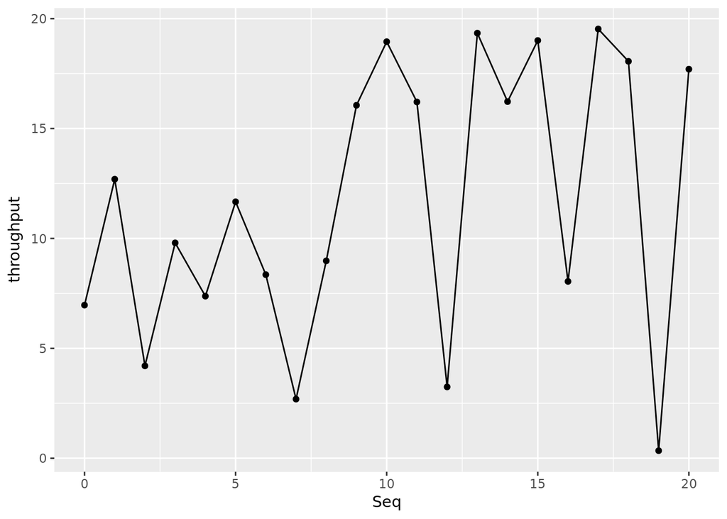

```r
library(ggplot2)
library(readr)
library(reshape)
library(reshape2)
tahoe <- read_csv("~/networking/renoc++.csv")
tahoe$throughput <- (tahoe$timeReceived - tahoe$timeSent)
ggplot(data=tahoe, aes(x=Seq, y=throughput)) + geom_line() + geom_point()
```

## Tahoe

Following Information was our input, it also would not use the checksum properly, it just ignores if we return that a packet was corrupted, did not know what to do with it, even after implementing checksum when we were not technically suppose to, so data slightly off but this is what we got.

Enter the number of messages to simulate: 20  
Enter packet loss probability [enter 0.0 for no loss]:0.5  
Enter packet corruption probability [0.0 for no corruption]:0.5  
Enter average time between messages from sender’s layer5 [ > 0.0]:15  
Enter TRACE:3  
GENERATE NEXT ARRIVAL: creating new arrival  
INSERTEVENT: time is 0.000000  
INSERTEVENT: future time will be 10.448565

EVENT time: 10.448565, type: 1, fromlayer5 entity: 0  
GENERATE NEXT ARRIVAL: creating new arrival  
INSERTEVENT: time is 10.448565  
INSERTEVENT: future time will be 29.492790  
MAINLOOP: data given to student: aaaaaaaaaaaaaaaaaaaa

EVENT time: 29.492790, type: 1, fromlayer5 entity: 0  
GENERATE NEXT ARRIVAL: creating new arrival  
INSERTEVENT: time is 29.492790  
INSERTEVENT: future time will be 35.796394  
MAINLOOP: data given to student: bbbbbbbbbbbbbbbbbbbb

EVENT time: 35.796394, type: 1, fromlayer5 entity: 0  
GENERATE NEXT ARRIVAL: creating new arrival  
INSERTEVENT: time is 35.796394  
INSERTEVENT: future time will be 50.492714  
MAINLOOP: data given to student: cccccccccccccccccccc

EVENT time: 50.492714, type: 1, fromlayer5 entity: 0  
GENERATE NEXT ARRIVAL: creating new arrival  
INSERTEVENT: time is 50.492714  
INSERTEVENT: future time will be 61.553432  
MAINLOOP: data given to student: dddddddddddddddddddd

EVENT time: 61.553432, type: 1, fromlayer5 entity: 0  
GENERATE NEXT ARRIVAL: creating new arrival  
INSERTEVENT: time is 61.553432  
INSERTEVENT: future time will be 79.055817  
MAINLOOP: data given to student: eeeeeeeeeeeeeeeeeeee

EVENT time: 79.055817, type: 1, fromlayer5 entity: 0  
GENERATE NEXT ARRIVAL: creating new arrival  
INSERTEVENT: time is 79.055817  
INSERTEVENT: future time will be 91.582977  
MAINLOOP: data given to student: ffffffffffffffffffff

EVENT time: 91.582977, type: 1, fromlayer5 entity: 0  
GENERATE NEXT ARRIVAL: creating new arrival  
INSERTEVENT: time is 91.582977  
INSERTEVENT: future time will be 95.617813  
MAINLOOP: data given to student: gggggggggggggggggggg

EVENT time: 95.617813, type: 1, fromlayer5 entity: 0  
GENERATE NEXT ARRIVAL: creating new arrival  
INSERTEVENT: time is 95.617813  
INSERTEVENT: future time will be 109.088631  
MAINLOOP: data given to student: hhhhhhhhhhhhhhhhhhhh

EVENT time: 109.088631, type: 1, fromlayer5 entity: 0  
GENERATE NEXT ARRIVAL: creating new arrival  
INSERTEVENT: time is 109.088631  
INSERTEVENT: future time will be 133.176712  
MAINLOOP: data given to student: iiiiiiiiiiiiiiiiiiii

EVENT time: 133.176712, type: 1, fromlayer5 entity: 0  
GENERATE NEXT ARRIVAL: creating new arrival  
INSERTEVENT: time is 133.176712  
INSERTEVENT: future time will be 161.603821  
MAINLOOP: data given to student: jjjjjjjjjjjjjjjjjjjj

EVENT time: 161.603821, type: 1, fromlayer5 entity: 0  
GENERATE NEXT ARRIVAL: creating new arrival  
INSERTEVENT: time is 161.603821  
INSERTEVENT: future time will be 185.918976  
MAINLOOP: data given to student: kkkkkkkkkkkkkkkkkkkk

EVENT time: 185.918976, type: 1, fromlayer5 entity: 0  
GENERATE NEXT ARRIVAL: creating new arrival  
INSERTEVENT: time is 185.918976  
INSERTEVENT: future time will be 190.786530  
MAINLOOP: data given to student: llllllllllllllllllll

EVENT time: 190.786530, type: 1, fromlayer5 entity: 0  
GENERATE NEXT ARRIVAL: creating new arrival  
INSERTEVENT: time is 190.786530  
INSERTEVENT: future time will be 219.797318  
MAINLOOP: data given to student: mmmmmmmmmmmmmmmmmmmm

EVENT time: 219.797318, type: 1, fromlayer5 entity: 0  
GENERATE NEXT ARRIVAL: creating new arrival  
INSERTEVENT: time is 219.797318  
INSERTEVENT: future time will be 244.137085  
MAINLOOP: data given to student: nnnnnnnnnnnnnnnnnnnn

EVENT time: 244.137085, type: 1, fromlayer5 entity: 0  
GENERATE NEXT ARRIVAL: creating new arrival  
INSERTEVENT: time is 244.137085  
INSERTEVENT: future time will be 272.647339  
MAINLOOP: data given to student: oooooooooooooooooooo

EVENT time: 272.647339, type: 1, fromlayer5 entity: 0  
GENERATE NEXT ARRIVAL: creating new arrival  
INSERTEVENT: time is 272.647339  
INSERTEVENT: future time will be 284.713684  
MAINLOOP: data given to student: pppppppppppppppppppp

EVENT time: 284.713684, type: 1, fromlayer5 entity: 0  
GENERATE NEXT ARRIVAL: creating new arrival  
INSERTEVENT: time is 284.713684  
INSERTEVENT: future time will be 314.008453  
MAINLOOP: data given to student: qqqqqqqqqqqqqqqqqqqq

EVENT time: 314.008453, type: 1, fromlayer5 entity: 0  
GENERATE NEXT ARRIVAL: creating new arrival  
INSERTEVENT: time is 314.008453  
INSERTEVENT: future time will be 341.097198  
MAINLOOP: data given to student: rrrrrrrrrrrrrrrrrrrr

EVENT time: 341.097198, type: 1, fromlayer5 entity: 0  
GENERATE NEXT ARRIVAL: creating new arrival  
INSERTEVENT: time is 341.097198  
INSERTEVENT: future time will be 341.612854  
MAINLOOP: data given to student: ssssssssssssssssssss

EVENT time: 341.612854, type: 1, fromlayer5 entity: 0  
GENERATE NEXT ARRIVAL: creating new arrival  
INSERTEVENT: time is 341.612854  
INSERTEVENT: future time will be 368.165466  
MAINLOOP: data given to student: tttttttttttttttttttt

EVENT time: 368.165466, type: 1, fromlayer5 entity: 0  
Simulator terminated at time 368.165466  
after sending 20 msgs from layer5

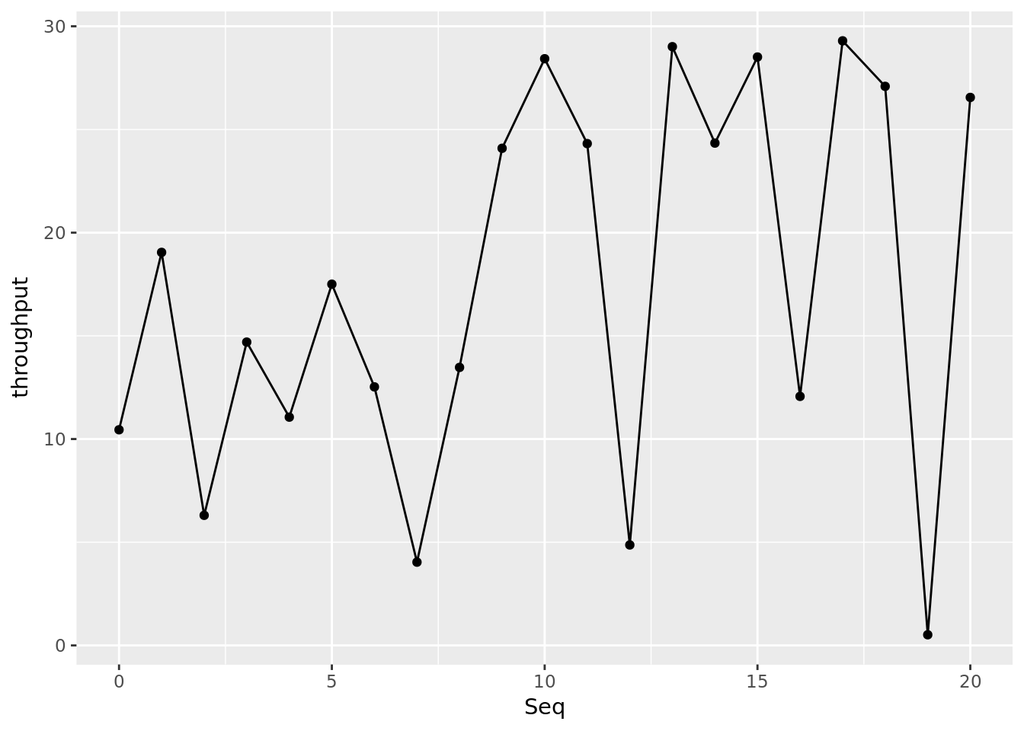

```r
library(ggplot2)
library(readr)
library(reshape)
library(reshape2)
tahoe <- read_csv("~/networking/tahoec++.csv")
tahoe$throughput <- (tahoe$timeReceived - tahoe$timeSent)
ggplot(data=tahoe, aes(x=Seq, y=throughput)) + geom_line() + geom_point()
```